# *fpmoutliers* - Outlier detection using frequent pattern mining

Jaroslav Kuchař

2017-04-02

R implementation of algorithms for detection of outliers based on frequent pattern mining. They follow the paradigm: if an instance contains more frequent patterns, it means that this data instance is unlikely to be an anomaly.

## Algorithms and References

Available implementations:

- FPCOF - Frequent Pattern Contradiction Outlier Factor
  - X. Tang, G. Li and G. Chen, “Fast Detecting Outliers over Online Data Streams,” 2009 International Conference on Information Engineering and Computer Science, Wuhan, 2009, pp. 1-4. [link](http://ieeexplore.ieee.org/abstract/document/5363123/)
- FPOF - Frequent Pattern Outlier Factor
  - He, Z., Xu, X., Huang, J. Z., Deng, S.: FP-Outlier: Frequent Pattern Based Outlier Detection. Computer Science and Information Systems, Vol. 2, No. 1, 103-118. (2005). [link](http://www.comsis.org/archive.php?show=pprnnn-2106)
- LFPOF - L. Frequent Pattern Outlier Factor
  - W. Zhang, J. Wu and J. Yu, “An Improved Method of Outlier Detection Based on Frequent Pattern,” Information Engineering (ICIE), 2010 WASE International Conference on, Beidaihe, Hebei, 2010, pp. 3-6. [link](http://ieeexplore.ieee.org/document/5571194/)
- MFPOF - Maximal Frequent Pattern Outlier Factor
  - Feng Lin, Wang Le, Jin Bo - Research on Maximal Frequent Pattern Outlier Factor for Online HighDimensional Time-Series Outlier Detection. Journal of Convergence Information Technology 5(10):66-71 · December 2010. [link](http://citeseerx.ist.psu.edu/viewdoc/summary?doi=10.1.1.592.2752)
- WCFPOF - Weighted Closed Frequent Pattern Outlier Factor
  - Jiadong Ren, Qunhui Wu, Changzhen Hu, and Kunsheng Wang. 2009. An Approach for Analyzing Infrequent Software Faults Based on Outlier Detection. In Proceedings of the 2009 International Conference on Artificial Intelligence and Computational Intelligence - Volume 04 (AICI ’09), Vol. 4. IEEE Computer Society, Washington, DC, USA, 302-306. [link](http://dl.acm.org/citation.cfm?id=1723929)
- WFPOF - Weighted Frequent Pattern Outlier Factor
  - ZHOU Xiao-Yun+, SUN Zhi-Hui, ZHANG Bai-Li, YANG Yi-Dong - A Fast Outlier Detection Algorithm for High Dimensional Categorical Data Streams. Journal of Software 18(4) · April 2007. [link](http://en.cnki.com.cn/Article_en/CJFDTOTAL-RJXB200704015.htm)
- FPI, WFPI - Frequent Pattern Isolation, Weighted Frequent Pattern Isolation
  - TBD

## Installation

```bash
library("devtools")
devtools::install_github("jaroslav-kuchar/fpmoutliers")
```

## Examples

### Initial Example

Data initialization

```r
# libraries
library(mlbench)
library(fpmoutliers)

# initialize data
data(BreastCancer)
dataFrame <- BreastCancer[2:10]
```

Compute scores:

```r
# compute scores and sort
model <- FPI(dataFrame, minSupport = 0.01)
sortedDataFrame <- dataFrame[order(model$scores, decreasing = TRUE),]
```

Anomaly:

```r
# instance with the highest anomaly score
out <- describeInstance(sortedDataFrame, model, 1)
```

```
## Details for the instance: 99
## * Outlier score: 98.74
## * Coverage of the instance: 8  of  9 attributes ( 88.8888888888889 %)
## * Number of matching frequent itemsets: 10
## * Frequent itemsets (top-10):
##                            itemset    support
## 8                  {Bl.cromatin=2} 0.23748212
## 7                {Marg.adhesion=2} 0.08297568
## 6                {Epith.c.size=10} 0.04434907
## 5                    {Cell.size=6} 0.03862661
## 4              {Normal.nucleoli=9} 0.02288984
## 2                 {Cl.thickness=9} 0.02002861
## 3                     {Mitoses=10} 0.02002861
## 10 {Marg.adhesion=2,Bl.cromatin=2} 0.01716738
## 1                   {Cell.shape=9} 0.01001431
## 9     {Epith.c.size=10,Mitoses=10} 0.01001431
## * Participations of attributes:
##    Cl.thickness=9       Cell.size=6      Cell.shape=9   Marg.adhesion=2
##          49.92857          25.88889          99.85714          20.58836
##   Epith.c.size=10     Bare.nuclei=6     Bl.cromatin=2 Normal.nucleoli=9
##          36.23848         699.00000          16.66792          43.68750
##        Mitoses=10
##          49.92857
```

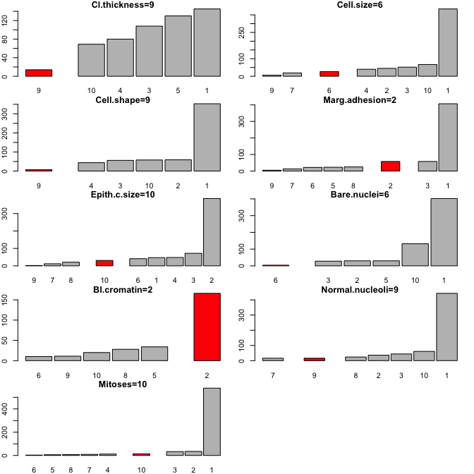

```r
visualizeInstance(sortedDataFrame, 1)
```

Regular instance:

```r
# instance with the lowest anomaly score
out <- describeInstance(sortedDataFrame, model, nrow(sortedDataFrame))
```

```
## Details for the instance: 687
## * Outlier score: 1.96
## * Coverage of the instance: 9  of  9 attributes ( 100 %)
## * Number of matching frequent itemsets: 511
## * Frequent itemsets (top-10):
##                          itemset   support
## 9                    {Mitoses=1} 0.8283262
## 8            {Normal.nucleoli=1} 0.6337625
## 45 {Normal.nucleoli=1,Mitoses=1} 0.6094421
## 7              {Marg.adhesion=1} 0.5822604
## 6                {Bare.nuclei=1} 0.5751073
## 42     {Bare.nuclei=1,Mitoses=1} 0.5565093
## 44   {Marg.adhesion=1,Mitoses=1} 0.5550787
## 5               {Epith.c.size=2} 0.5522175
## 4                  {Cell.size=1} 0.5493562
## 35       {Cell.size=1,Mitoses=1} 0.5393419
## * Participations of attributes:
##    Cl.thickness=1       Cell.size=1      Cell.shape=1   Marg.adhesion=1
##          2.663412          1.784095          1.864110          1.834827
##    Epith.c.size=2     Bare.nuclei=1     Bl.cromatin=1 Normal.nucleoli=1
##          1.931917          1.859556          2.658980          1.751788
##         Mitoses=1
##          1.747661
```

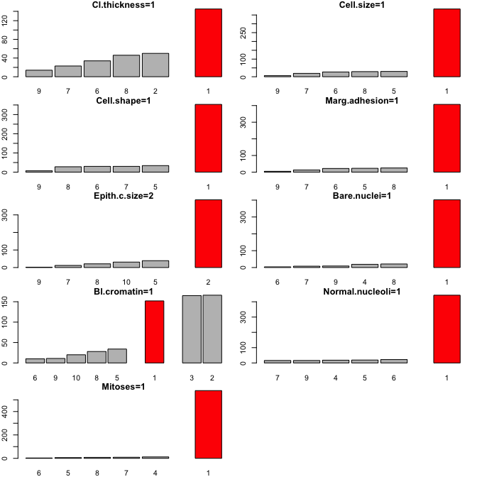

```r
visualizeInstance(sortedDataFrame, nrow(sortedDataFrame))
```

## Contributors

- Jaroslav Kuchař (https://github.com/jaroslav-kuchar)

## Licence

Apache License Version 2.0